# APPENDIX

Yuriy Davydenko

8/17/2020

### Evaluation of the Effectiveness of the Ready2Read Vocabulary-Building Program

```r
library(readr)
library(dplyr)
library(ggplot2)
library(scales)
library(knitr)
library(kableExtra)
library(pander)
library(gridExtra)
```

#### READ THE DATA IN

Ready2Read performance measures:

```r
r2r <- read_csv("Data/ready2readprograminfo.csv", col_names = T,
                cols(
                    student_id = col_integer(),
                    ready2read = col_integer(),
                    met_half_Ready2Read_goal = col_integer(),
                    met_all_Ready2Read_goal = col_integer(),
                    pre_fluency_score = col_double(),
                    post_fluency_score = col_double()
                    ) )
```

Demographics:

```r
demographics <- xlsx::read.xlsx("Data/data_warehouse_pull.xlsx", 1)
```

English Learner:

```r
el <- read_table("Data/english_learners.prn",
                  col_names = c("student_id", "el"), skip = 1,
                  cols(student_id = col_integer(), el = col_integer()))
```

Exceptional students:

```r
excep <- readr::read_table("Data/exceptional_students_list.prn",
                  col_names = c("student_id", "excep"), skip = 1,
                  cols(student_id = col_integer(), excep = col_integer()))
```

Talented and gifted:

```r
tag <- tibble::as_tibble(read.table("Data/tag_students.raw", sep = ",", col.names = c("student_id", "tag") ) )
```

#### Joining Tables

```r
data <- dplyr::left_join(r2r, demographics, by = "student_id") %>%
        dplyr::left_join(el, by = "student_id") %>%
        dplyr::left_join(excep, by = "student_id") %>%
        dplyr::left_join(tag, by = "student_id")
```

The first five rows of the joined dataset:

```r
pander::panderOptions('table.split.table', 135)
pander::pander(head(data, n=5))
```

Table continues below

| student_id | ready2read | met_half_Ready2Read_goal | met_all_Ready2Read_goal | pre_fluency_score | post_fluency_score | school_id |
| --- | --- | --- | --- | --- | --- | --- |
| 822873 | 0 | 0 | 0 | 124 | 140 | 350 |
| 819909 | 0 | 0 | 0 | 99 | 116 | 350 |
| 823158 | 0 | 0 | 0 | 127 | 144 | 350 |
| 817200 | 0 | 0 | 0 | 78 | 101 | 350 |
| 821965 | 0 | 0 | 0 | 115 | 134 | 350 |

Table continues below

| grade | frpl | male | white | black | asian | hispanic | multiracial | personalized_learning | title_1 | magnet | region_bridges |
| --- | --- | --- | --- | --- | --- | --- | --- | --- | --- | --- | --- |
| 4 | 1 | 0 | 1 | 0 | 0 | 0 | 0 | 1 | 1 | 0 | 0 |
| 5 | 1 | 0 | 0 | 0 | 0 | 1 | 0 | 1 | 1 | 0 | 0 |
| 4 | 1 | 1 | 0 | 1 | 0 | 0 | 0 | 1 | 1 | 0 | 0 |
| 5 | 1 | 1 | 0 | 1 | 0 | 0 | 0 | 1 | 1 | 0 | 0 |
| 5 | 1 | 1 | 0 | 0 | 0 | 1 | 0 | 1 | 1 | 0 | 0 |

| region_harris | region_benjamin | region_patton | region_simpson | region_robinson | region_raymond | el | excep | tag |
| --- | --- | --- | --- | --- | --- | --- | --- | --- |
| 0 | 0 | 0 | 1 | 0 | 0 | 0 | 0 | 0 |
| 0 | 0 | 0 | 1 | 0 | 0 | 0 | 0 | 0 |
| 0 | 0 | 0 | 1 | 0 | 0 | 0 | 0 | 0 |
| 0 | 0 | 0 | 1 | 0 | 0 | 0 | 1 | 0 |
| 0 | 0 | 0 | 1 | 0 | 0 | 1 | 0 | 0 |

#### DESCRIPTIVE STATISTICS & EXPLORATORY ANALYSIS

Ready2Read program participation status:

```r
data %>% count(ready2read) %>% mutate(Percent = round(n / nrow(data), 2)) %>%
         kable(align = "l") %>% kable_styling(bootstrap_options = c("compact", "hover"))
```

| ready2read | n | Percent |
| --- | --- | --- |
| 0 | 7741 | 0.48 |
| 1 | 8480 | 0.52 |

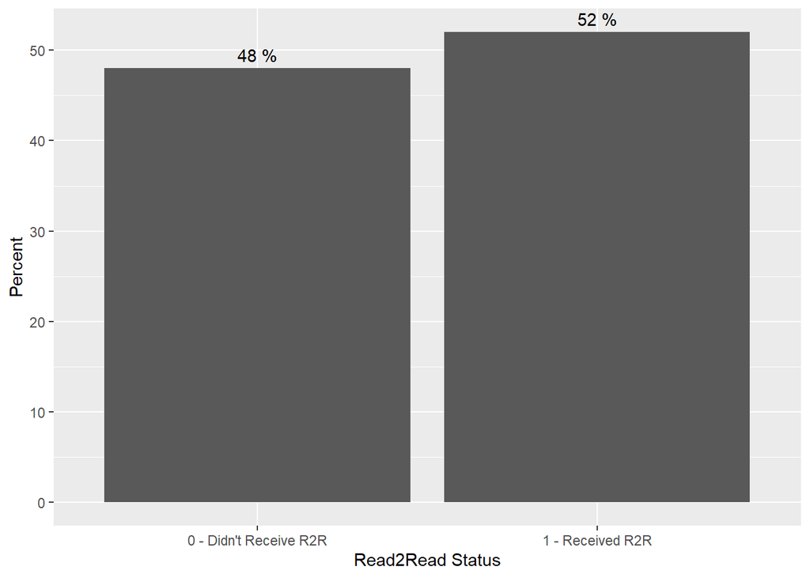

```r
data %>% count(ready2read) %>% mutate(Percent = 100*round(n / nrow(data), 2)) %>%
         ggplot(aes(x = as.factor(ready2read), y = Percent)) + geom_bar(stat = "identity") +
         geom_text(aes(label = paste(Percent, "%"), vjust = -.5 )) +
         scale_x_discrete(labels = c("0 - Didn't Receive R2R", "1 - Received R2R")) +
         xlab("Read2Read Status")
```

Percentage of participants who met half of Ready2Read goals:

```r
participants <- data %>% filter(ready2read == 1)
participants %>% count(met_half_Ready2Read_goal) %>% mutate(Percent = round(n / nrow(participants), 2)) %>%
                 kable(align = "l") %>% kable_styling(bootstrap_options = c("compact", "hover"))
```

| met_half_Ready2Read_goal | n | Percent |
| --- | --- | --- |
| 0 | 2676 | 0.32 |
| 1 | 5804 | 0.68 |

```r
participants %>% count(met_all_Ready2Read_goal) %>% mutate(Percent = round(n / nrow(participants), 2)) %>%
                 kable(digits = 2, align = "l") %>% kable_styling(bootstrap_options = c("compact", "hover"))
```

| met_all_Ready2Read_goal | n | Percent |
| --- | --- | --- |
| 0 | 4874 | 0.57 |
| 1 | 3606 | 0.43 |

Distribution of the fluency assessment score across treatment conditions (0 = Nonparticipants, 1 = Participants):

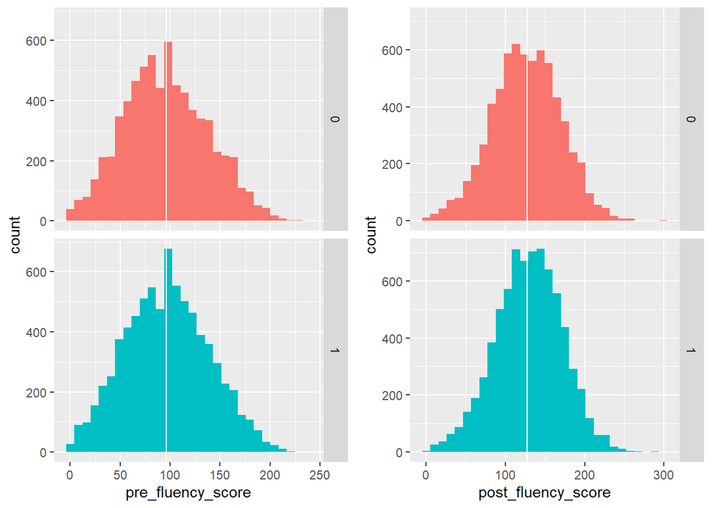

```r
hist_pre <- data %>% ggplot(aes(x = pre_fluency_score, fill = factor(ready2read) )) +
                        geom_histogram() +
                        geom_vline(xintercept = mean(data$pre_fluency_score, na.rm = T), color = "white") +
                        theme(legend.position="none") +
                        facet_grid(factor(ready2read) ~ .)

hist_post <- data %>% ggplot(aes(x = post_fluency_score, fill = factor(ready2read) )) +
                        geom_histogram() +
                        geom_vline(xintercept = mean(data$post_fluency_score, na.rm = T), color = "white") +
                        theme(legend.position="none") +
                        facet_grid(factor(ready2read) ~ .)

grid.arrange(hist_pre, hist_post, ncol = 2)
```

#### MEAN OUTCOMES ACROSS TREATMENTS

**Explanatory variable:** `ready2read`

Pre-post mean fluency assessment scores across treatment groups:

```r
eff_size_r2r <-
data %>% group_by(ready2read) %>%
            summarise(mean_pre_fluency_score = mean(pre_fluency_score, na.rm = T),
                      mean_post_fluency_score = mean(post_fluency_score, na.rm = T))


eff_size_r2r %>% kable(digits = 2, align = "l") %>% kable_styling(bootstrap_options = c("compact", "hover"))
```

| ready2read | mean_pre_fluency_score | mean_post_fluency_score |
| --- | --- | --- |
| 0 | 95.73 | 125.98 |
| 1 | 96.71 | 129.23 |

Pre-post mean fluency assessment scores across treatment groups (visualization):

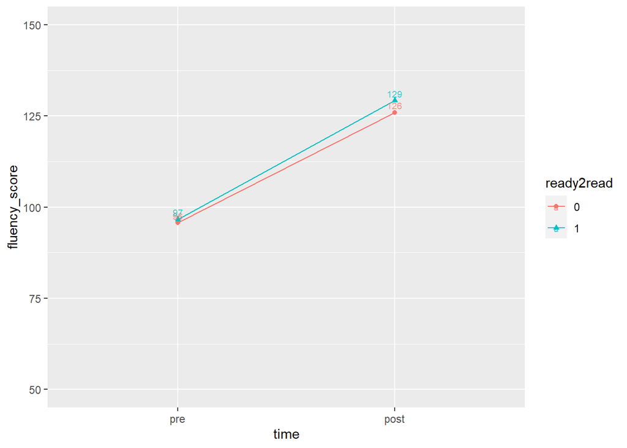

```r
plot_r2r <-
data %>% group_by(ready2read) %>% summarise(mean_pre_fluency_score = mean(pre_fluency_score, na.rm = T),
                                            mean_post_fluency_score = mean(post_fluency_score, na.rm = T)) %>%
        rename(pre = mean_pre_fluency_score, post = mean_post_fluency_score) %>%
        mutate(ready2read = factor(ready2read)) %>%
        tidyr::gather(time, fluency_score, -ready2read) %>%
        mutate(time = factor(time, levels = c("pre", "post") )) %>%
        ggplot(aes(x = time, y = fluency_score, group=ready2read, shape=ready2read, col=ready2read)) +
        geom_line() + geom_point() + ylim(50, 150) +
        geom_text(aes(label = round(fluency_score, 0)), size = 2.5, vjust = -0.5, alpha=0.75)

plot_r2r
```

```r
# Defining a visualization function to apply to subsamples:
viz <- function(d){
d %>% group_by(ready2read) %>% summarise(mean_pre_fluency_score = mean(pre_fluency_score, na.rm = T),
                                            mean_post_fluency_score = mean(post_fluency_score, na.rm = T)) %>%
        rename(pre = mean_pre_fluency_score, post = mean_post_fluency_score) %>%
        mutate(ready2read = factor(ready2read)) %>%
        tidyr::gather(time, fluency_score, -ready2read) %>%
        mutate(time = factor(time, levels = c("pre", "post") )) %>%
        ggplot(aes(x = time, y = fluency_score, group=ready2read, shape=ready2read, col=ready2read)) +
        geom_line() + geom_point() + ylim(50, 150) +
        geom_text(aes(label = round(fluency_score, 0)), size = 2.5, vjust = -0.5, alpha = 0.75)
}
```

Cohen’s d (standardized) effect size for the first difference in the nonparticipant group:

```r
round(
(eff_size_r2r$mean_post_fluency_score[1] - eff_size_r2r$mean_pre_fluency_score[1]) /
sd(c(data$pre_fluency_score, data$post_fluency_score), na.rm = T),
digits = 2)
```

```
## [1] 0.67
```

Standardized effect size for the difference-in-difference effect:

```r
round(
((eff_size_r2r$mean_post_fluency_score[2] - eff_size_r2r$mean_pre_fluency_score[2]) -
(eff_size_r2r$mean_post_fluency_score[1] - eff_size_r2r$mean_pre_fluency_score[1])) /
sd(c(data$pre_fluency_score, data$post_fluency_score), na.rm = T),
digits = 2)
```

```
## [1] 0.05
```

Differences for those students who met half of R2R goals:

```r
data %>% filter(ready2read==0 | met_half_Ready2Read_goal==1) %>%
        group_by(ready2read) %>% summarise(mean_pre_fluency_score = mean(pre_fluency_score, na.rm = T),
                                            mean_post_fluency_score = mean(post_fluency_score, na.rm = T) )
```

```
## # A tibble: 2 x 3
##   ready2read mean_pre_fluency_score mean_post_fluency_score
##        <int>                  <dbl>                   <dbl>
## 1          0                   95.7                    126.
## 2          1                   98.0                    130.
```

Differences for those students who met all of R2R goals:

```r
data %>% filter(ready2read==0 | met_all_Ready2Read_goal==1) %>%
        group_by(ready2read) %>% summarise(mean_pre_fluency_score = mean(pre_fluency_score, na.rm = T),
                                            mean_post_fluency_score = mean(post_fluency_score, na.rm = T) )
```

```
## # A tibble: 2 x 3
##   ready2read mean_pre_fluency_score mean_post_fluency_score
##        <int>                  <dbl>                   <dbl>
## 1          0                   95.7                    126.
## 2          1                  101.                     134.
```

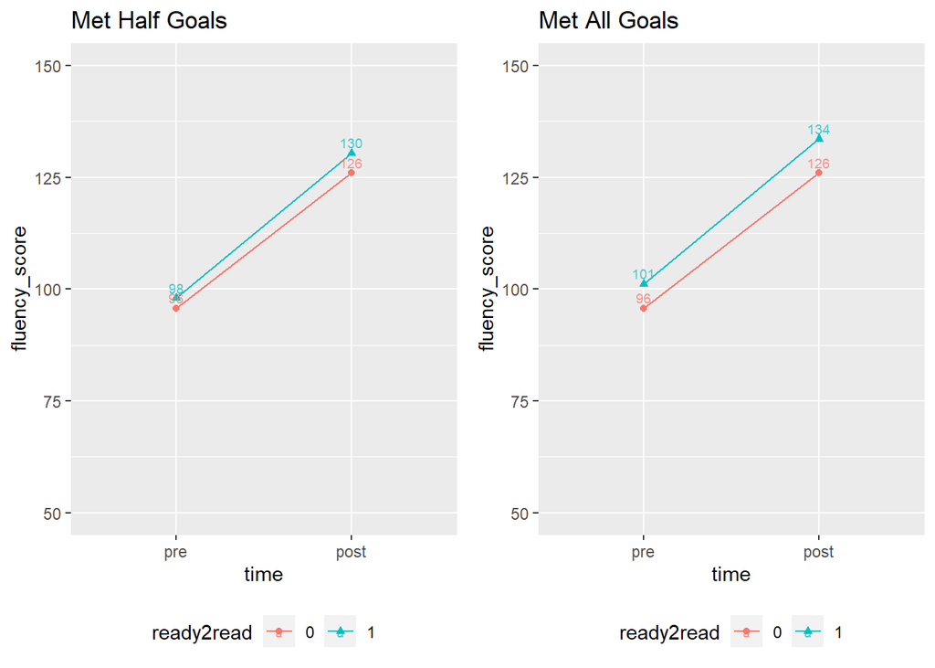

```r
half <-
data %>% filter(ready2read==0 | met_half_Ready2Read_goal==1) %>%
        group_by(ready2read) %>% summarise(mean_pre_fluency_score = mean(pre_fluency_score, na.rm = T),
                                            mean_post_fluency_score = mean(post_fluency_score, na.rm = T)) %>%
        rename(pre = mean_pre_fluency_score, post = mean_post_fluency_score) %>%
        mutate(ready2read = factor(ready2read)) %>%
        tidyr::gather(time, fluency_score, -ready2read) %>%
        mutate(time = factor(time, levels = c("pre", "post") )) %>%
        ggplot(aes(x = time, y = fluency_score, group=ready2read, shape=ready2read, col=ready2read)) +
        geom_line() + geom_point() + ylim(50, 150) +
        geom_text(aes(label = round(fluency_score, 0)), size = 2.5, vjust = -0.5, alpha=0.75)

all <-
data %>% filter(ready2read==0 | met_all_Ready2Read_goal==1) %>%
        group_by(ready2read) %>% summarise(mean_pre_fluency_score = mean(pre_fluency_score, na.rm = T),
                                            mean_post_fluency_score = mean(post_fluency_score, na.rm = T)) %>%
        rename(pre = mean_pre_fluency_score, post = mean_post_fluency_score) %>%
        mutate(ready2read = factor(ready2read)) %>%
        tidyr::gather(time, fluency_score, -ready2read) %>%
        mutate(time = factor(time, levels = c("pre", "post") )) %>%
        ggplot(aes(x = time, y = fluency_score, group=ready2read, shape=ready2read, col=ready2read)) +
        geom_line() + geom_point() + ylim(50, 150) +
        geom_text(aes(label = round(fluency_score, 0)), size = 2.5, vjust = -0.5, alpha=0.75)

grid.arrange( (half + theme(legend.position="bottom") + labs(title = "Met Half Goals") ),
              (all + theme(legend.position="bottom") + labs(title = "Met All Goals")), ncol = 2)
```

#### Controlled Difference-In-Difference Estimate

Reshaping the dataset to the proper panel-data format & creating the `time` (0=pre, 1=post) variable

```r
data_pre <- data %>% select(-post_fluency_score) %>% rename(fluency_score = pre_fluency_score) %>%
            mutate(time = 0)
data_post <- data %>% select(-pre_fluency_score) %>% rename(fluency_score = post_fluency_score) %>%
            mutate(time = 1)
data_prepost <- rbind(data_pre, data_post)
```

Difference-in-difference estimates for:

1. `ready2read` all participants,
2. participants who met half of Ready2Read goals,
3. participants who met all of Ready2Read goals

```r
# all Ready2Read participants:
did1 <-
lm(fluency_score ~ ready2read*time +
                    school_id + grade + frpl + personalized_learning + title_1 + magnet + el + excep + tag +
                    male + black + asian + hispanic + multiracial +
                    region_bridges + region_harris + region_benjamin +
                    region_patton + region_simpson + region_robinson,
                    data = data_prepost)

# met_half_Ready2Read_goal:
did2 <-
lm(fluency_score ~ ready2read*time +
                    school_id + grade + frpl + personalized_learning + title_1 + magnet + el + excep + tag +
                    male + black + asian + hispanic + multiracial +
                    region_bridges + region_harris + region_benjamin +
                    region_patton + region_simpson + region_robinson,
                    data = data_prepost[data_prepost$ready2read==0 | data_prepost$met_half_Ready2Read_goal==1,])

# met_all_Ready2Read_goal
did3 <-
lm(fluency_score ~ ready2read*time +
                    school_id + grade + frpl + personalized_learning + title_1 + magnet + el + excep + tag +
                    male + black + asian + hispanic + multiracial +
                    region_bridges + region_harris + region_benjamin +
                    region_patton + region_simpson + region_robinson,
                    data = data_prepost[data_prepost$ready2read==0 | data_prepost$met_all_Ready2Read_goal==1,])


sjPlot::tab_model(did1, did2, did3, digits = 2, digits.p = 3, show.se = TRUE, show.p = FALSE, p.style = "star", show.ci = FALSE)
```

fluency_score

fluency_score

fluency_score

Predictors

Estimates

std. Error

Estimates

std. Error

Estimates

std. Error

(Intercept)

71.25 ***

8.80

93.01 ***

10.62

100.48 ***

11.83

ready2read

0.46

0.61

-0.22

0.68

2.04 **

0.75

time

30.09 ***

0.58

30.02 ***

0.57

30.00 ***

0.57

school_id

-0.01

0.02

-0.07 *

0.03

-0.08 **

0.03

grade

12.60 ***

0.18

12.48 ***

0.20

11.94 ***

0.21

frpl

-14.13 ***

0.51

-13.56 ***

0.55

-13.51 ***

0.59

personalized_learning

2.81 ***

0.52

4.97 ***

0.59

4.50 ***

0.62

title_1

-2.75 ***

0.50

-3.85 ***

0.61

-3.32 ***

0.65

magnet

-2.21 **

0.81

-6.76 ***

1.11

-6.68 ***

1.13

el

-16.92 ***

0.77

-16.76 ***

0.85

-16.39 ***

0.90

excep

-28.54 ***

0.63

-29.03 ***

0.68

-29.44 ***

0.74

tag

30.16 ***

0.93

31.22 ***

1.01

31.74 ***

1.07

male

-4.48 ***

0.40

-4.55 ***

0.43

-4.79 ***

0.46

black

-13.20 ***

0.57

-12.82 ***

0.62

-12.80 ***

0.66

asian

6.60 ***

1.11

6.71 ***

1.16

5.98 ***

1.22

hispanic

-6.45 ***

0.73

-6.41 ***

0.79

-6.27 ***

0.85

multiracial

-4.37 ***

1.00

-3.40 **

1.08

-3.15 **

1.16

region_bridges

-4.11 ***

0.64

-2.52 ***

0.74

-3.30 ***

0.78

region_harris

9.87 ***

1.22

9.20 ***

1.26

9.92 ***

1.27

region_benjamin

1.58

0.86

0.45

1.09

0.70

1.11

region_patton

1.92 **

0.69

4.37 ***

0.78

3.71 ***

0.89

region_simpson

1.43 *

0.67

0.51

0.73

0.97

0.81

region_robinson

1.40

1.00

6.43 ***

1.24

6.72 ***

1.28

ready2read * time

2.29 **

0.79

2.31 **

0.87

2.47 *

0.97

Observations

28593

23833

20604

R<sup>2</sup> / R<sup>2</sup> adjusted

0.449 / 0.448

0.454 / 0.453

0.452 / 0.451

- p<0.05 ** p<0.01 *** p<0.001

#### Estimates for Subpopulations

**Subpopulation:** Students with exceptionalities: `excep` = 1

```r
eff_size_r2r_excep <-
data %>% filter(excep == 1) %>%
            group_by(ready2read) %>%
            summarise(mean_pre_fluency_score = mean(pre_fluency_score, na.rm = T),
                                            mean_post_fluency_score = mean(post_fluency_score, na.rm = T))

eff_size_r2r_excep %>% kable(digits = 2, align = "l") %>%
            kable_styling(bootstrap_options = c("compact", "hover"))
```

| ready2read | mean_pre_fluency_score | mean_post_fluency_score |
| --- | --- | --- |
| 0 | 63.62 | 89.20 |
| 1 | 70.46 | 107.25 |

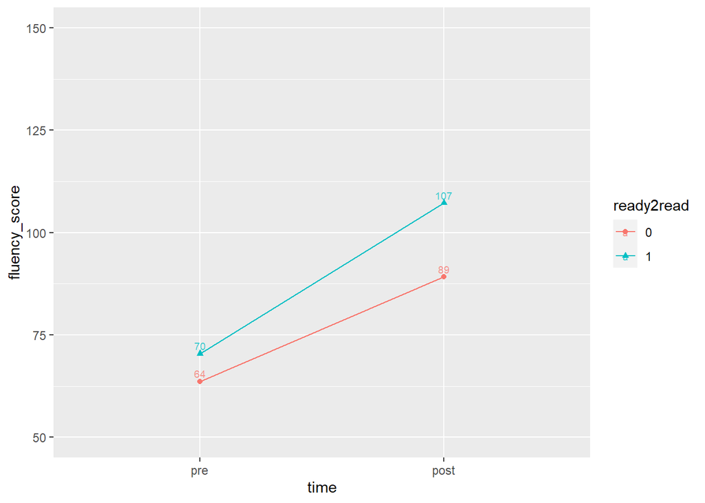

```r
d_excep <- data %>% filter(excep == 1)
plot_excep <- viz(d_excep)
plot_excep
```

Difference-in-difference estimate for students with exceptionalities `excep`:

```r
did4 <-
lm(fluency_score ~ ready2read*time +
                    school_id + grade + frpl + personalized_learning + title_1 + magnet + el + tag +
                    male + black + asian + hispanic + multiracial +
                    region_bridges + region_harris + region_benjamin +
                    region_patton + region_simpson + region_robinson,
                    data = data_prepost[data_prepost$excep==1,])

sjPlot::tab_model(did4, digits = 2, digits.p = 3, show.se = TRUE, show.p = FALSE, p.style = "star", show.ci = FALSE)
```

fluency_score

Predictors

Estimates

std. Error

(Intercept)

97.00 ***

28.63

ready2read

3.05

1.96

time

25.53 ***

1.82

school_id

-0.15

0.08

grade

12.52 ***

0.57

frpl

-20.07 ***

1.59

personalized_learning

1.05

1.66

title_1

-5.64 ***

1.61

magnet

-5.01

2.76

el

-12.82 ***

2.65

tag

50.50 ***

7.17

male

-0.01

1.37

black

-13.75 ***

1.79

asian

3.05

5.96

hispanic

-3.75

2.52

multiracial

-12.87 ***

3.19

region_bridges

-1.48

2.01

region_harris

-4.08

4.32

region_benjamin

-1.28

2.79

region_patton

-0.61

2.10

region_simpson

0.98

2.20

region_robinson

-0.67

3.33

ready2read * time

11.11 ***

2.53

Observations

3340

R<sup>2</sup> / R<sup>2</sup> adjusted

0.369 / 0.365

- p<0.05 ** p<0.01 *** p<0.001

Standardized effect size:

```r
round(
((eff_size_r2r_excep$mean_post_fluency_score[2] - eff_size_r2r_excep$mean_pre_fluency_score[2]) -
(eff_size_r2r_excep$mean_post_fluency_score[1] - eff_size_r2r_excep$mean_pre_fluency_score[1])) /
    sd(c(d_excep$pre_fluency_score, d_excep$post_fluency_score), na.rm = T),
digits = 2)
```

```
## [1] 0.25
```

Visual comparison of the difference-in-difference effects for the whole pilot population and students with exceptionalities:

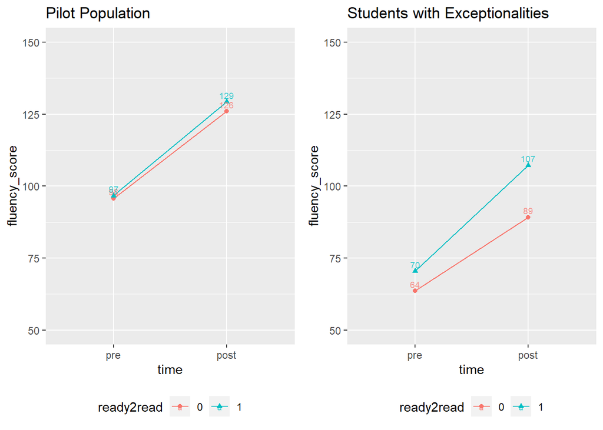

```r
grid.arrange( (plot_r2r + theme(legend.position="bottom") + labs(title = "Pilot Population")),
              (plot_excep + theme(legend.position="bottom") + labs(title = "Students with Exceptionalities")),
               ncol=2 )
```